# The Net Present Value of the Billionaire Tax Act

- Show All Code
- Hide All Code
- View Source

A reproduction of Rauh, Jaros, Kearney, Doran and Cosso (SSRN, March 2026) and Jaros and Rauh (NBER, September 2026), the opposing side’s analysis of California Proposition 40

Published

September 23, 2026

Part of an Open Policy Analysis of Rauh et al. (2026) on California Proposition 40: Open Output (the explorer) · Open Analysis: Report (here) and Slides · Open Materials · Overview

**setup: every number below is read from the {targets} store**

````r
suppressPackageStartupMessages({
  library(targets); library(dplyr); library(knitr); library(ggplot2)
})
store <- "../_targets"                       # opposing-analysis/_targets
tr <- function(name) tar_read_raw(name, store = store)
for (f in list.files("../R", pattern = "\\.R$", full.names = TRUE)) source(f)

rc   <- tr("revenue_chain")
pf   <- tr("pareto_fit")
sch  <- tr("pareto_income_schedule")
t8   <- tr("income_tax_table8")
itmc <- tr("income_tax_mc")
t9   <- tr("npv_table9")
t10  <- tr("npv_table10")
mcs  <- tr("npv_mc_ssrn")
mcn  <- tr("npv_mc_nber")
nc   <- tr("nber_ceiling")
ncol <- tr("nber_collectible")
hl   <- tr("site_headlines")
grid <- tr("site_grid")
inputs  <- read.csv("../export/r/inputs.csv")
outputs <- read.csv("../export/r/outputs.csv")
printed <- read.csv("data/printed-tables.csv")
ss <- formals(compute_npv_mc_ssrn); nb <- formals(compute_npv_mc_nber)
# HTML tables: pandoc would read a pair of "$" across markdown table cells as math
options(knitr.table.format = "html")

# formatting: a real minus sign, fixed decimals
num <- function(x, d = 1) {
  s <- formatC(abs(x), format = "f", digits = d, big.mark = ",")
  ifelse(x < 0, paste0("−", s), s)
}
pct <- function(x, d = 1) paste0(num(x, d), "%")
out <- function(id, col = "value") outputs[[col]][outputs$output_id == id]
inp <- function(id) inputs$value[inputs$input_id == id]
h <- function(v, q, col = "reproduced") hl[[col]][hl$version == v & hl$quantity == q]
# raw HTML block: pandoc must not read "$B ... $B" inside a table as a math span
scroll <- function(x) cat("\n\n```{=html}\n<div class=\"table-scroll\">\n",
                          as.character(x), "\n</div>\n```\n\n", sep = "")
````

## Introduction

This report rebuilds, step by step, the opposing side’s fiscal score of California’s Proposition 40 (the Billionaire Tax Act): a one-time 5% tax on the net worth of billionaires resident in California on 1 January 2026. The authors argue that the tax would collect far less than its proponents expect, and that billionaires who leave take their income tax with them for ever, so the state ends up poorer. Following the [Open Policy Analysis](https://tinyurl.com/1qypbihb) framework:

- **Open Output**: the explorer, the mean net present value and share of negative outcomes for every combination of seven inputs
- **Open Analysis**: this document, and the slide deck
- **Open Materials**: the materials page, every script, test, CSV and source, with all nine mismatches found along the way

**What is reproduced.** Two versions of one analysis, side by side, as fixed in the project’s pre-specified output before any results were seen:

1. **SSRN 6340778** (Rauh, Jaros, Kearney, Doran and Cosso, Hoover Institution, 17 March 2026). Headline: revenue of about $40B and a mean NPV of −24.7 $B, with 71% of simulated outcomes negative (PDF p.1).
2. **NBER chapter c15504** (Jaros and Rauh, 22 September 2026), the litigation-weighted revision. Headline: revenue of about $30B ($28.4B to $35.6B) and a mean NPV of −38.9 $B, with 85.2% negative.

Both are reproduced from the authors’ own public, MIT-licensed code and data (github.com/bjaros20/wealth_tax, pinned at commit `25e84dd`): their Excel workbooks are read cell by cell, their R scripts are ported line by line and also re-run unmodified, and the NBER person-level file `final.csv` is summed directly. Every number in this document is read from the project’s `{targets}` pipeline at render time; the only numbers typed in are the papers’ printed values we compare against, each with its PDF page (page numbers are PDF pages throughout).

**The shape of the argument**, in one line: net present value = wealth tax collected once, minus the present value of the income tax that departing billionaires would have paid in every future year. Sections 4 and 5.1 of the paper estimate the two pieces; Sections 5.2 to 5.5 combine them. We follow that order, then list what the NBER revision changes.

### Notation, in one place

| Symbol | Meaning | Unit |
| --- | --- | --- |
| $\tau$ | statutory wealth tax rate | share |
| $WT$ | one-time wealth tax revenue actually collected | $B |
| $C$ | annual California income tax paid by the billionaires | $B per year |
| $f$ | share of that income tax base that leaves the state | share |
| $r$ | real discount rate (the Monte Carlo’s draw) | per year |
| $g$ | real growth of the lost income tax stream | per year |
| $\varepsilon$ | migration semi-elasticity: % of the base lost per percentage point of tax |  |
| $q$ | probability the Act survives constitutional challenge (NBER only) | probability |
| NPV | $WT - f \cdot C/r$ (or $/(r-g)$), the net fiscal effect today | $B |

## Section 4: the wealth tax revenue

### 4.1 The baseline, before anyone leaves (eq. 3)

$$R_{\text{baseline}} = \sum_{i=1}^{N} \tau \times \text{TaxBase}_i$$

In words: take each of the $N$ = 212 California billionaires on the 2025 Forbes list (with the authors’ corrections), subtract their directly held residential real estate (the Act exempts it), multiply what is left by the 5% rate, and add up. Their aggregate net worth is $1,894.8B. The workbook’s own row-by-row sum gives **$94.30B**; the paper prints $94.20B (p.10). The difference is mismatch 6: the paper’s text rounds the workbook’s cell, and every later step then uses the typed literal 94.2 rather than the workbook’s own sum. We reproduce the code, so later steps use 94.2 too.

### 4.2 The six confirmed departures (eq. 4, 6 to 8)

$$R_{\text{adjusted}} = \sum_{i=1}^{N} (1 - \text{Departed}_i) \times \tau \times \text{TaxBase}_i$$

The same sum, dropping anyone publicly reported to have moved out before the 1 January 2026 residency date: Page, Brin, Thiel, Hankey, Spielberg and Sacks (Table 6, p.11). Revenue falls to **$67.51B** (printed: $67.51B). The paper then asks how big a behavioural response that is. It divides the share of revenue lost by the rate change, in percentage points (eq. 5):

$$\varepsilon = \frac{\%\Delta \text{TaxBase}}{\Delta \text{TaxRate (p.p.)}}
= \frac{(94.20 - 67.51)/94.20}{5} = 5.67$$

**the implied semi-elasticities, recomputed**

```r
eps6  <- 100 * (1 - rc$confirmed6_ceiling / rc$baseline_literal) / (100 * inp("tax_rate"))
eps10 <- 100 * (1 - rc$expanded10_estimate / rc$baseline_literal) / (100 * inp("tax_rate"))
c(confirmed_6 = eps6, expanded_10 = eps10)
```

```
confirmed_6 expanded_10
   5.666529    8.302261
```

A semi-elasticity of 5.67 means that a 1-point tax rate rise drives out about 5.7% of the base. The authors treat this as a floor because it counts only departures that made the news.

### 4.3 The expanded departures (eq. 9 to 11)

Adding four more reported or rumoured leavers (Zuckerberg after the snapshot date; Koum, Hastings and Fang unconfirmed; Table 7, p.12), revenue falls to **$55.10B** (printed $55.1B), and the implied semi-elasticity rises to 8.30. The paper argues that people who left after the snapshot date may still escape the tax, because the retroactive residency date may not survive in court (pp.12-13).

### 4.4 The literature calibration (eq. 12 to 14)

$$\varepsilon_{\text{lit}} = 0.24 \times 43.00 = 10.32, \qquad
R^{\text{lit}} = (1 - \varepsilon_{\text{lit}} \times 0.05) \times 94.20$$

Brülhart et al. (2022) estimate that Swiss taxable wealth falls by 43% per point of wealth tax, about 24% of it through people moving. The authors keep only the moving part, 10.32, and apply it linearly to the full 5-point rate: the base shrinks by 51.6% and revenue is **$45.59B** (printed $45.59B). Two things to notice. First, that is a Swiss estimate for a recurring annual tax, applied here to a one-time tax; the paper argues a one-time tax with easy interstate moves could provoke a *larger* response (p.14), and the supporting side disputes exactly this ([disputes row 1](https://github.com/fhoces/opa-prop40/blob/main/comparison/DISPUTES.md)). Second, a linear 10.32 × 5 = 51.6% loss is steeper than the log form the NBER revision later uses (41.1%, NBER PDF p.23).

### 4.5 The preferred revenue estimate

The paper settles on “approximately $40 billion (range: $35-46 billion)” (p.14). The top of the range is the literature calibration, $45.59B. The bottom comes from a judgement that the true semi-elasticity is 12 to 13 (footnote 6, p.14), which the authors call “plausible and conservative”. The $40B point itself is not computed anywhere in the authors’ code; it sits near the middle of that range. **Labelled guesswork** in this reproduction.

## Section 5.1: the income tax the billionaires pay

### The Pareto upper bound (eq. 15 and 16)

$$N(y) = A\,y^{-\alpha}, \qquad S(k, n) = \left(\frac{k}{n}\right)^{(\alpha - 1)/\alpha}$$

The state publishes how many tax returns report income above $1M, $2M, $3M, $4M, $5M and $10M (FTB PIT Annual Report 2024, Table B-4A). If top incomes follow a Pareto distribution, the log of those counts falls on a straight line against the log of the thresholds, with slope $-\alpha$. The fitted line gives $\hat\alpha$ = **1.438** (printed 1.44, $R^2$ = 0.9987).

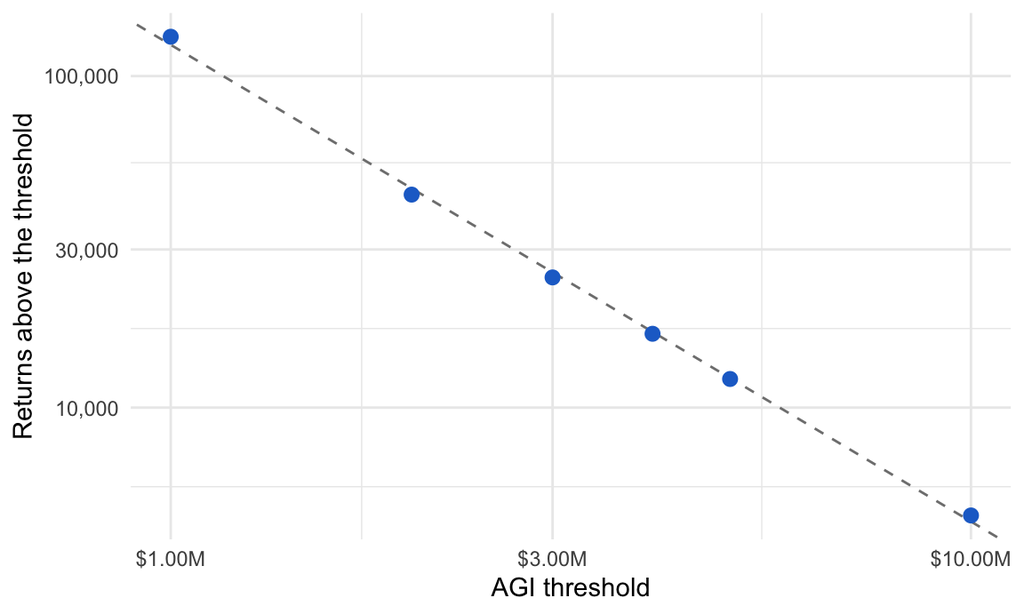

The six published filer counts against their AGI thresholds, log-log, with the fitted Pareto line (paper Figure 1).

```r
d <- data.frame(y = pf$thresholds, n = pf$filer_counts)
ggplot(d, aes(y, n)) +
  geom_abline(intercept = log10(pf$A), slope = -pf$alpha, linetype = 2, colour = "grey50") +
  geom_point(size = 2.5, colour = "#1f6fce") +
  scale_x_log10(labels = scales::label_dollar(scale = 1e-6, suffix = "M")) +
  scale_y_log10(labels = scales::label_comma()) +
  labs(x = "AGI threshold", y = "Returns above the threshold") +
  theme_minimal(base_size = 11)
```

$S(k, n)$ is the share of the bracket’s income that goes to its top $k$ of $n$ filers. With the top 212 of the 4,729 filers above $10M, the continuous formula gives 38.8% of the bracket’s $11.1B of tax. The script then builds a rank-by-rank income schedule and rescales it by 1.118 so that its top 212 match the continuous share (footnote 12: the discrete sum undershoots by about 11%). Scaling Tax Year 2023 to FY 2024-25 collections ($130B in total) multiplies by 1.335. If the billionaires *are* the 212 highest earners, they pay **$5.76B a year**. That is the upper bound, and the top of $C$’s range.

### The dispersion Monte Carlo (Table 8)

Billionaires are ranked by wealth, not income, and many realise little income in a given year. So the script places the 212 billionaires at random among the top $K$ filers (without replacement, 100,000 draws for each $K$ from 212 to 2,000) and sums their tax. The wider the pool, the lower the expected total. The authors take $K \approx 500$ (“roughly the top decile of the bracket”) as a reasonable floor, which gives the bottom of $C$’s range, $3.3B. The choice of $K$ = 500 is a judgement, not an estimate, so the range $C \in [3.3, 5.8]$ is labelled **guesswork** below.

**Table 8: reproduced (seed 42, the authors’ RNG stream replayed) vs printed**

```r
p8 <- printed[printed$table == "table8", ]
pv <- function(k, col) p8$printed[p8$row == k & p8$column == col]
tab8 <- t8 %>% transmute(
  `Pool size K` = format(K, big.mark = ","),
  `Mean` = num(mean_fy25, 3), `printed` = sapply(K, pv, "mean"),
  `P5` = num(p05_fy25, 3), `printed ` = sapply(K, pv, "p05"),
  `P95` = num(p95_fy25, 3), `printed  ` = sapply(K, pv, "p95"))
m8 <- sum(round(t8$mean_fy25, 2) == sapply(t8$K, pv, "mean")) +
      sum(round(t8$p05_fy25, 2) == sapply(t8$K, pv, "p05")) +
      sum(round(t8$p95_fy25, 2) == sapply(t8$K, pv, "p95"))
scroll(kable(tab8, align = "rrrrrrr", caption = "Table 8, $B per year (PDF p.17)"))
```

Table 8, $B per year (PDF p.17)

| Pool size K | Mean | printed | P5 | printed | P95 | printed |
| --- | --- | --- | --- | --- | --- | --- |
| 212 | 5.757 | 5.76 | 5.757 | 5.76 | 5.757 | 5.76 |
| 250 | 5.181 | 5.18 | 4.785 | 4.79 | 5.453 | 5.45 |
| 300 | 4.609 | 4.61 | 4.136 | 4.14 | 5.007 | 5.01 |
| 400 | 3.828 | 3.83 | 3.331 | 3.33 | 4.314 | 4.31 |
| 500 | 3.308 | 3.31 | 2.829 | 2.83 | 3.818 | 3.82 |
| 750 | 2.536 | 2.54 | 2.116 | 2.12 | 3.033 | 3.03 |
| 1,000 | 2.099 | 2.10 | 1.726 | 1.73 | 2.572 | 2.57 |

21 of the 21 cells round to the printed value; the tests hold this at the printed rounding (`tests/testthat/test-income-tax-mc.R`).

## Section 5.2: from an annual loss to a present value (eq. 17 to 20)

$$PV = \frac{C}{r}, \qquad NPV = WT - f \cdot \frac{C}{r}$$

$$\text{or, with growth:}\qquad PV = \frac{C}{r - g}, \qquad NPV = WT - f \cdot \frac{C}{r - g}$$

This is the step that makes the result. The wealth tax is collected **once**. The income tax of anyone who leaves is lost **every year, for ever**, and a perpetuity paying $C$ a year is worth $C/r$ today. At $r$ = 1.5% a perpetuity is worth 1/0.015, about 67 years of payments; at 4.5%, about 22. The paper’s text then argues the lost stream grows with the billionaires’ wealth, making it a growing perpetuity, $C/(r-g)$, and calibrates $r - g$ at about 1.5% from the S&P 500’s dividend yield (p.18).

Two things are worth knowing before reading the tables:

- **Which rate is drawn.** Tables 9 and 10 label their rates $(r-g)$. The Monte Carlo in Sec 5.5 draws “$r$” and computes $C/r$. The SSRN code (`NPV_dist.R:60`) divides by the plain draw, and the NBER code draws the same interval but calls it $(r-g)$ (mismatches 2 and 3). Numerically nothing changes, because the same interval is used whatever it is called; conceptually, the interval is asked to stand for two different things. The explorer’s growth dial shows what the ambiguity is worth.
- **The horizon.** Treating the loss as permanent is itself one of the disputed choices: the supporting side scores the loss as lasting about the five payment years ([disputes row 2](https://github.com/fhoces/opa-prop40/blob/main/comparison/DISPUTES.md)).

## Section 5.3: NPV by departure scenario (Table 9)

Three scenarios, each a revenue figure paired with an income tax figure, each at three rates. The departure share is implied by the revenue: $f = 1 - WT/94.20$, so revenue lost and income tax lost move together ([disputes row 6](https://github.com/fhoces/opa-prop40/blob/main/comparison/DISPUTES.md) questions that proportionality).

**Table 9 from compute_npv_table9() (NPV_calculations_5.2.xlsx ported) vs printed**

```r
p9 <- printed[printed$table == "table9", ]
t9p <- t9 %>% mutate(key = paste0(scenario, "@", r)) %>% rowwise() %>% mutate(
  pv_printed = p9$printed[p9$row == key & p9$column == "pv_lost"],
  npv_printed = p9$printed[p9$row == key & p9$column == "npv"]) %>% ungroup()
tab9 <- t9p %>% transmute(Scenario = label, `WT ($B)` = num(WT, 2), `C ($B)` = num(C, 2),
  `f` = pct(100 * f), `r - g` = pct(100 * r),
  `PV lost` = num(pv_lost), `printed` = num(pv_printed),
  `NPV` = num(npv), `printed ` = num(npv_printed))
m9 <- sum(abs(round(t9p$pv_lost, 1) - t9p$pv_printed) < 1e-9) + sum(abs(round(t9p$npv, 1) - t9p$npv_printed) < 1e-9)
scroll(kable(tab9, align = "lrrrrrrrr", caption = "Table 9, $B (PDF p.19)"))
```

Table 9, $B (PDF p.19)

| Scenario | WT ($B) | C ($B) | f | r - g | PV lost | printed | NPV | printed |
| --- | --- | --- | --- | --- | --- | --- | --- | --- |
| Central Scenario | 42.00 | 4.55 | 55.4% | 1.5% | 168.1 | 168.1 | −126.1 | −126.1 |
| Central Scenario | 42.00 | 4.55 | 55.4% | 3.0% | 84.0 | 84.0 | −42.0 | −42.0 |
| Central Scenario | 42.00 | 4.55 | 55.4% | 4.5% | 56.0 | 56.0 | −14.0 | −14.0 |
| Only 6 Confirmed Departures | 67.51 | 3.30 | 28.3% | 1.5% | 62.3 | 62.3 | 5.2 | 5.2 |
| Only 6 Confirmed Departures | 67.51 | 3.30 | 28.3% | 3.0% | 31.2 | 31.2 | 36.3 | 36.3 |
| Only 6 Confirmed Departures | 67.51 | 3.30 | 28.3% | 4.5% | 20.8 | 20.8 | 46.7 | 46.7 |
| Literature Calibrated Departures | 35.00 | 5.80 | 62.8% | 1.5% | 243.0 | 243.0 | −208.0 | −208.0 |
| Literature Calibrated Departures | 35.00 | 5.80 | 62.8% | 3.0% | 121.5 | 121.5 | −86.5 | −86.5 |
| Literature Calibrated Departures | 35.00 | 5.80 | 62.8% | 4.5% | 81.0 | 81.0 | −46.0 | −46.0 |

18 of the 18 cells match the printed digit. The central scenario’s $42B is a typed literal with no derivation anywhere (mismatch 8), which is why the input table labels it **scenario**. Note that the headline $−24.7B is *not* a cell of this table: the central cell at 1.5% is −126.1 $B. The headline is the Monte Carlo mean of Sec 5.5.

## Section 5.4: the break-even departure share (Table 10, eq. 21)

$$x^* = \frac{WT \cdot (r - g)}{C}$$

Set NPV to zero and solve for the departure share: the tax pays for itself only if fewer than $x^*$ of the income tax base leaves. The script computes $WT \cdot r / C$ with the drawn rate.

**Table 10 from compute_npv_table10() vs printed**

```r
p10 <- printed[printed$table == "table10", ]
tab10 <- t10 %>% mutate(key = paste0(scenario, "@", r)) %>% rowwise() %>%
  mutate(printed = p10$printed[p10$row == key]) %>% ungroup() %>%
  transmute(Scenario = label, `r - g` = pct(100 * r), `x*` = pct(100 * break_even_pct),
            printed = pct(printed))
m10 <- sum(abs(round(100 * t10$break_even_pct, 1) -
  sapply(paste0(t10$scenario, "@", t10$r), function(k) p10$printed[p10$row == k])) < 1e-9)
scroll(kable(tab10, align = "lrrr", caption = "Table 10 (PDF p.20)"))
```

Table 10 (PDF p.20)

| Scenario | r - g | x* | printed |
| --- | --- | --- | --- |
| Central Scenario | 1.5% | 13.8% | 13.8% |
| Central Scenario | 3.0% | 27.7% | 27.7% |
| Central Scenario | 4.5% | 41.5% | 41.5% |
| Only 6 Confirmed Departures | 1.5% | 30.7% | 30.7% |
| Only 6 Confirmed Departures | 3.0% | 61.4% | 61.4% |
| Only 6 Confirmed Departures | 4.5% | 92.1% | 92.1% |
| Literature Calibrated Departures | 1.5% | 9.1% | 9.1% |
| Literature Calibrated Departures | 3.0% | 18.1% | 18.1% |
| Literature Calibrated Departures | 4.5% | 27.2% | 27.2% |

9 of the 9 cells match. A check that is not an input: plugging each $x^*$ back into the Table 9 formula must give an NPV of exactly zero (see internal identities).

## Section 5.5: the Monte Carlo behind the headline (eq. 22 to 24)

$$WT \sim U[\$35\text{B}, \$67.1\text{B}], \quad C \sim U[\$3.3\text{B}, \$5.8\text{B}], \quad
r \sim U[0.015, 0.045]$$

$$f = 1 - WT/94.20, \qquad NPV = WT - f\cdot C/r$$

Draw the three inputs independently and uniformly, 100,000 times, and average the NPV. Three details matter:

1. **The printed upper bound 67.1 is a typo for 67.51** (mismatch 1). The code uses 67.51; with 67.1 the printed mean does not come out.
2. **The discount term is $C/r$, not $C/(r-g)$** (mismatch 2), over the whole 1.5% to 4.5% band.
3. **The draw’s revenue range is not the preferred revenue.** $WT \sim U[35, 67.51]$ has a mean of $51.26B, above the paper’s own preferred $40B, because the ceiling (only the six confirmed departures) enters as the top of the draw.

**Sec 5.5: seeded reproduction vs printed, both versions**

```r
mk <- function(v, lab) {
  s <- if (v == "ssrn") tr("npv_mc_ssrn_summary") else tr("npv_mc_nber_summary")
  data.frame(Version = lab,
    `Mean` = num(s$mean, 2), `printed` = num(h(v, "mc_mean_npv", "printed")),
    `Median` = num(s$median, 2), `printed ` = num(h(v, "mc_median_npv", "printed")),
    `SD` = num(s$sd, 2), `printed  ` = num(h(v, "mc_sd_npv", "printed")),
    `% negative` = num(s$pct_negative, 2), `printed   ` = num(h(v, "mc_pct_negative", "printed")),
    check.names = FALSE)
}
scroll(kable(rbind(mk("ssrn", "SSRN (p.20)"), mk("nber", "NBER (p.35)")),
             align = "lrrrrrrrr", caption = "NPV Monte Carlo, $B, seed 2026, 100,000 draws"))
```

NPV Monte Carlo, $B, seed 2026, 100,000 draws

| Version | Mean | printed | Median | printed | SD | printed | % negative | printed |
| --- | --- | --- | --- | --- | --- | --- | --- | --- |
| SSRN (p.20) | −24.77 | −24.7 | −19.10 | −19.1 | 38.60 | 38.4 | 71.02 | 71.0 |
| NBER (p.35) | −38.89 | −38.9 | −35.26 | −35.3 | 37.62 | 37.6 | 85.17 | 85.2 |

Our R port replays the authors’ script exactly (same seed, same draw order) and agrees with an unmodified run of `NPV_dist.R` to machine precision. The SSRN median and share negative match the printed values. The mean (−24.77 against −24.7) and the standard deviation (38.60 against 38.4) do not quite (mismatch 9). The draws are independent, so the mean has a closed form:

$$E[NPV] = E[WT] - \left(1 - \frac{E[WT]}{94.20}\right) E[C]\, E\!\left[\tfrac{1}{r}\right]$$

$$E\!\left[\tfrac{1}{r}\right] = \frac{\ln(0.045/0.015)}{0.045 - 0.015}$$

It equals **−24.707 $B**, which rounds to the printed −24.7. So the printed mean is the model’s exact expectation, while the shipped seed gives −24.77. The printed SD stays unexplained.

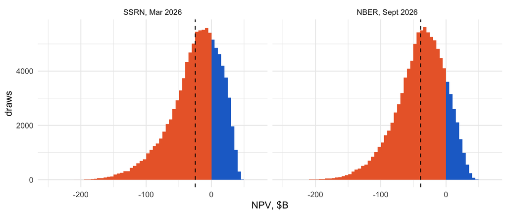

The distribution of simulated NPV, both versions (paper Figure 3). Draws below zero in orange; the dashed line is the mean.

```r
dd <- rbind(data.frame(v = "SSRN, Mar 2026", npv = mcs$draws$npv),
            data.frame(v = "NBER, Sept 2026", npv = mcn$draws$npv))
dd$v <- factor(dd$v, levels = c("SSRN, Mar 2026", "NBER, Sept 2026"))
mm <- dd %>% group_by(v) %>% summarise(m = mean(npv))
ggplot(dd, aes(npv, fill = npv < 0)) +
  geom_histogram(binwidth = 5, boundary = 0) +
  geom_vline(data = mm, aes(xintercept = m), linetype = 2) +
  scale_fill_manual(values = c(`TRUE` = "#eb6834", `FALSE` = "#1f6fce"), guide = "none") +
  facet_wrap(~v) + coord_cartesian(xlim = c(-250, 70)) +
  labs(x = "NPV, $B", y = "draws") + theme_minimal(base_size = 11)
```

## The NBER revision (September 2026)

The NBER version keeps Sections 4 and 5.1 (same base, same Pareto fit, same Table 8, now numbered Table 9) and changes the revenue side and the Monte Carlo. Five changes, in the order they enter:

1. **A later valuation date.** Net worth is grown 7% to the 31 December 2026 valuation date, and the base is rebuilt person by person in `final.csv`: 212 domestic rows, face value $100.91B (printed $100.9B).
2. **Seven confirmed departures** (the six, plus Travis Kalanick): removing them leaves **$72.05B**. The README says $72.06B and the script hard-codes 72 (mismatch 4); three numbers for one quantity. The 28 non-US-citizen residents ($146.3B of net worth) stay outside the base, now explicitly.
3. **A litigation discount** (PDF pp.19-23, eqs. 5 to 8). Removing three pre-filing departures and Zuckerberg leaves a recognized base of $59.15B; multiplying by $q$ = 0.5, the chance the Act survives in court, gives $E[R] = q \times R_{\text{recognized}}$ = **$29.57B** (printed $29.6B). Keeping Zuckerberg gives $35.59B; moving the gray-zone names out gives $28.40B, the printed range $28.4B to $35.6B. The choice of $q$ = 0.50 comes from an accounting standard for uncertain tax positions (ASC 740-10), not from a legal assessment; it is **guesswork**.
4. **The departure share is drawn on its own**, $f \sim U[0.3, 0.6]$, independent of revenue, “centered conservatively around the observed wealth-base departure fraction” (PDF p.30).
5. **The Monte Carlo draws revenue from zero**: $WT \sim U[0, 72]$ (PDF p.35, eq. 16). Its mean, $36B, is $0.5 \times 72$, which the paper calls the central estimate (PDF p.33). This is the only place $q$ appears in the code: there is no explicit multiplier (mismatch 5), and a uniform draw from 0 is a different assumption from a survive-or-not coin flip on a fixed base. The paper also states the income tax loss is not scaled by $q$: people who left do not come back if the Act is struck down (PDF p.33).

The NBER break-even table, from the same `compute_npv_table10()` at the paper’s central $36B and $4.55B:

**NBER Table 10 (PDF p.34): same function, NBER central inputs**

```r
wt36 <- 0.5 * nb$wt_max
n10 <- compute_npv_table10(scenarios = list(central = list(label = "Central", WT = wt36, C = 4.55)))
pn <- printed[printed$table == "nber_table10", ]
scroll(kable(n10 %>% transmute(`WT ($B)` = num(WT, 0), `C ($B)` = num(C, 2), `r - g` = pct(100 * r),
                               `x*` = pct(100 * break_even_pct),
                               printed = pct(pn$printed[match(paste0("central@", r), pn$row)])),
             align = "rrrrr", caption = "NBER Table 10 (PDF p.34)"))
```

NBER Table 10 (PDF p.34)

| WT ($B) | C ($B) | r - g | x* | printed |
| --- | --- | --- | --- | --- |
| 36 | 4.55 | 1.5% | 11.9% | 11.9% |
| 36 | 4.55 | 3.0% | 23.7% | 23.7% |
| 36 | 4.55 | 4.5% | 35.6% | 35.6% |

The NBER Monte Carlo reproduces its printed summary to within Monte Carlo error with no systematic gap (table above). Its exact expectation is −38.98 $B, which rounds to −39.0 rather than the printed −38.9: here the printed value is the seeded run’s, not the expectation. The explorer shows the exact expectations and says so.

## Every input, by origin

This section is not in either paper: it re-sorts every input by *how much evidence stands behind it*, the question a reader who wants to argue with the result has to answer first.

- **data**: read off a public dataset or the authors’ own person-level file, and recomputable from it.
- **research**: an estimate taken from a published paper.
- **guesswork**: set by assumption. Some are bounded by evidence, but no dataset or estimate pins the value itself.
- **scenario**: a choice about which policy or counterfactual is being scored.
- **derived**: a value another row implies.

**every input: the pipeline’s inputs.csv plus the explorer’s seven dials**

```r
dials <- site_dials(rc)
dial_rows <- do.call(rbind, lapply(dials, function(d) data.frame(
  input = d$key, what = d$label, `value(s)` = paste(d$labels, collapse = "; "),
  origin = d$origin, where = "explorer dial (R/site.R)", check.names = FALSE)))
inp_rows <- data.frame(input = inputs$input_id, what = inputs$description,
  `value(s)` = ifelse(is.na(inputs$value), "1.5% to 4.5%", vapply(inputs$value, function(v) format(signif(v, 6)), "")),
  origin = inputs$label, where = inputs$source, check.names = FALSE)
odf <- rbind(inp_rows, dial_rows)
scroll(kable(odf, caption = "Inputs by origin (export/r/inputs.csv, then the explorer's dials)"))
```

Inputs by origin (export/r/inputs.csv, then the explorer's dials)

| input | what | value(s) | origin | where |
| --- | --- | --- | --- | --- |
| n_billionaires | CA billionaires in the domestic base | 212 | data | CA_Billionaires_Revenues_and_Migration_final.xlsx!Summary_Preferred!D15 |
| baseline_net_worth | Aggregate net worth, 212 domestic billionaires | 1894.8 | data | CA_Billionaires_Revenues_and_Migration_final.xlsx!Summary_Preferred!E15 |
| tax_rate | Statutory wealth tax rate | 0.05 | data | CA_Billionaires_Revenues_and_Migration_final.xlsx!Calculations_Preferred!N3 |
| pareto_alpha | Pareto tail parameter fit to FTB AGI thresholds | 1.43789 | research | monte_carlo_sim.R:33-44 (FTB PIT Annual Report 2024, Table B-4A) |
| bracket_tax_ty23 | TY2023 tax liability, $10M+ AGI bracket | 11.1 | data | monte_carlo_sim.R:51 (FTB Table B-4A) |
| total_pit_fy25 | Total FY2024-25 PIT collections | 130 | data | monte_carlo_sim.R:89 (CA State Controller cash receipts) |
| brulhart_semi_elasticity | Migration semi-elasticity, Brulhart et al. (2022) | 10.32 | research | Summary_Preferred!I8 (paper eq.12) |
| wt_central_scenario | Table 9 Central Scenario wealth tax revenue (literal input, not linked to Sec 4's chain) | 42 | scenario | NPV_calculations_5.2.xlsx!B12 |
| rauh_mc_wt_min | Monte Carlo wealth tax floor (literature-calibrated scenario; semi-elasticity about 12.6) | 35 | guesswork | NPV_dist.R (wt ~ U[35, 67.51]); paper eq.22 and Table 9 |
| rauh_mc_c_min | Annual CA income tax of billionaires: lower bound of the draw | 3.3 | guesswork | NPV_dist.R; paper eq.23 (from the K=500 dispersion draw) |
| rauh_mc_c_max | Annual CA income tax of billionaires: upper bound of the draw | 5.8 | guesswork | NPV_dist.R; paper eq.23 (Pareto upper bound) |
| rauh_mc_r_min | Discount rate draw: lower bound | 0.015 | research | NPV_dist.R:47; paper eq.24 (S&P 500 dividend yield anchor p.18; eq.18-20 instead specify r-g) |
| rauh_mc_r_max | Discount rate draw: upper bound | 0.045 | research | NPV_dist.R:47; paper eq.24 |
| nber_mc_f_min | NBER departure fraction of the income tax base: lower bound (drawn independently of WT) | 0.3 | guesswork | NPV_dist_v8.R; Jaros and Rauh NBER c15504 Sec 5.4 |
| nber_mc_f_max | NBER departure fraction of the income tax base: upper bound | 0.6 | guesswork | NPV_dist_v8.R; Jaros and Rauh NBER c15504 Sec 5.4 |
| q_litigation_survival | Probability the Act survives constitutional challenge (ASC 740-10 more-likely-than-not) | 0.5 | guesswork | NBER_2026_litigation_weighted/README.md (assumptions table); not an explicit multiplier in NPV_dist_v8.R - see MISMATCHES.md #5 |
| nber_growth_rate | Growth applied to the Jan-1-2026 snapshot to the Dec-31-2026 valuation date | 0.07 | data | final.csv (net_worth_usd_7pct column); NBER README assumptions table |
| nber_ceiling_hardcoded | wt_max literal in NPV_dist_v8.R (script uses this, not the value re-derived from final.csv) | 72 | data | NPV_dist_v8.R:19 |
| nber_ceiling_recomputed | wt_max re-derived from final.csv: domestic total minus 7 removed_departed rows | 72.0515 | derived | R/nber_final.R:compute_nber_ceiling() from final.csv |
| nber_international_net_worth | 28 international billionaires excluded from the domestic base | 146.3 | data | final.csv (panel == international, net_worth_usd) |
| wt_lo | Revenue, low end of the draw ($B) | 0 (NBER); 35 (SSRN); 45.59 | guesswork | explorer dial (R/site.R) |
| wt_hi | Revenue, high end of the draw ($B) | 55.10; 67.51 (SSRN); 72 (NBER) | data | explorer dial (R/site.R) |
| q | Litigation survival, applied to revenue | 1 (as coded); 0.75; 0.50 | guesswork | explorer dial (R/site.R) |
| c | Annual billionaire income tax, C ($B) | 3.3 to 5.8; 3.3 only; 5.8 only | guesswork | explorer dial (R/site.R) |
| rate | Discount rate drawn, rho | 1.5% to 4.5%; 1.5% only; 4.5% only | guesswork | explorer dial (R/site.R) |
| f | Share of the income tax base that leaves, f | 1 - WT/94.2 (SSRN); U[0.30, 0.60] (NBER); 0.283 fixed | guesswork | explorer dial (R/site.R) |
| g | Growth of lost income, g (r vs r - g reading) | 0 (as coded); 0.5% (illustrative); 1.0% (illustrative) | guesswork | explorer dial (R/site.R) |

**how many of each kind**

```r
cnt <- as.data.frame(table(factor(odf$origin, levels = c("data", "research", "guesswork", "scenario", "derived"))))
names(cnt) <- c("origin", "rows")
n_guess_dials <- sum(vapply(dials, function(d) d$origin == "guesswork", logical(1)))
scroll(kable(cnt))
```

| origin | rows |
| --- | --- |
| data | 9 |
| research | 4 |
| guesswork | 12 |
| scenario | 1 |
| derived | 1 |

**The headline:** 6 of the 7 inputs that move the result in the explorer are guesswork. The one labelled data, the revenue ceiling, rests on a legal judgement about who counts as having left (disputes row 3). The data and research inputs (the Forbes base, the FTB brackets, the Pareto fit, the Swiss semi-elasticity) fix the *scale*; whether the NPV is negative is decided by the guesswork: how wide the revenue draw is, where the income tax range stops, which rate is used, and whether the lost income tax is permanent.

## What reproduces

**every exported output against its printed value (export/r/outputs.csv)**

```r
o <- outputs %>% transmute(output = output_id, version, reproduced = signif(value, 6),
  printed = printed_value, `abs diff` = signif(abs_diff, 2),
  page = ifelse(is.na(printed_page), "NBER", printed_page))
scroll(kable(o))
```

| output | version | reproduced | printed | abs diff | page |
| --- | --- | --- | --- | --- | --- |
| pareto_alpha | both | 1.43789 | 1.44 | 0.00210 | 15 |
| income_tax_mc_k212 | both | 5.75702 | 5.76 | 0.00300 | 17 |
| income_tax_mc_k300 | both | 4.60902 | 4.61 | 0.00098 | 17 |
| income_tax_mc_k500 | both | 3.30815 | 3.31 | 0.00180 | 17 |
| revenue_baseline | both | 94.30430 | 94.20 | 0.10000 | 10 |
| revenue_confirmed6 | both | 67.51060 | 67.51 | 0.00065 | 11 |
| revenue_expanded10 | both | 55.09640 | 55.10 | 0.00360 | 13 |
| revenue_literature_calibrated | ssrn | 45.59280 | 45.59 | 0.00280 | 14 |
| table9_central_npv_r015 | ssrn | -126.08900 | -126.10 | 0.01100 | 19 |
| npv_mc_ssrn_mean | ssrn | -24.76810 | -24.70 | 0.06800 | 20 |
| npv_mc_ssrn_median | ssrn | -19.10040 | -19.10 | 0.00045 | 20 |
| npv_mc_ssrn_sd | ssrn | 38.59550 | 38.40 | 0.20000 | 20 |
| npv_mc_ssrn_pct_negative | ssrn | 71.02400 | 71.00 | 0.02400 | 20 |
| nber_domestic_grown | nber | 100.90600 | 100.90 | 0.00560 | NBER |
| nber_ceiling | nber | 72.05150 | 72.06 | 0.00850 | NBER |
| nber_international | nber | 146.30000 | 146.30 | 0.00000 | NBER |
| npv_mc_nber_mean | nber | -38.88630 | -38.90 | 0.01400 | NBER |
| npv_mc_nber_median | nber | -35.25550 | -35.30 | 0.04500 | NBER |
| npv_mc_nber_pct_negative | nber | 85.17200 | 85.20 | 0.02800 | NBER |

Every figure reproduces from the authors’ own code to within the tolerances in `tests/testthat/` (printed rounding for deterministic figures, four Monte Carlo standard errors for simulated ones). The largest gap is npv_mc_ssrn_sd (0.20), mismatch 9. 9 discrepancies were found between the papers, their READMEs and their code. We record them rather than fix them:

**the nine mismatches, parsed from MISMATCHES.md**

```r
mm_lines <- grep("^## [0-9]+\\.", readLines("../MISMATCHES.md"), value = TRUE)
cat(paste0(sub("^## ", "", mm_lines), collapse = "\n"), "\n\nFull text: [the materials page](materials.html#mismatches).\n")
```

1. Eq. 22’s printed WT upper bound (67.1) vs. the code’s literal (67.51)
2. NPV formula: growing perpetuity (eq. 18/20, `r-g`) vs. plain-`r` code (Sec 5.5)
3. NBER’s `rg_discount` draw reuses the SSRN plain-`r` range for an `(r-g)` quantity
4. NBER ceiling: hard-coded 72 vs. 72.05/72.06 derivable from `final.csv`
5. `q = 0.50` litigation-survival weight has no explicit multiplier in the code
6. Baseline revenue: workbook’s precise 94.30 vs. the literal 94.2 used downstream
7. `Summary_Expanded!D23:D24` reads from the wrong sheet (stale copy-paste)
8. Table 9’s Central Scenario (WT=$42.0B) has no derivation
9. SSRN Sec 5.5 printed summary (mean -$24.7B, sd $38.4B) does not exactly reproduce

Full text: the materials page.

### Internal identities

Checks against things that are not inputs to anything:

**internal consistency checks**

```r
x10 <- t10 %>% left_join(t9 %>% select(scenario, r, WT, C), by = c("scenario", "r", "WT", "C"))
npv_at_breakeven <- with(x10, WT - break_even_pct * C / r)
s_cell <- site_grid_cell(grid, as.list(site_named()$ssrn))
n_cell <- site_grid_cell(grid, as.list(site_named()$nber))
se_s <- mcs$summary$sd / sqrt(mcs$summary$n); se_n <- mcn$summary$sd / sqrt(mcn$summary$n)
checks <- data.frame(
  identity = c(
    "Table 10's x* plugged into Table 9's formula gives NPV = 0 (max |NPV|, $B)",
    "Grid's SSRN cell equals the pipeline's analytic mean (abs diff, $B)",
    "Grid's NBER cell equals the pipeline's analytic mean (abs diff, $B)",
    "SSRN seeded MC mean vs exact expectation, in MC standard errors",
    "NBER seeded MC mean vs exact expectation, in MC standard errors",
    "SSRN share negative: quadrature vs seeded MC (points)",
    "NBER share negative: quadrature vs seeded MC (points)",
    "NBER ceiling: domestic total minus the 7 departures, recomputed minus the script's 72 ($B)"),
  value = c(max(abs(npv_at_breakeven)),
    abs(s_cell$mean_npv - tr("npv_mc_ssrn_analytic_mean")),
    abs(n_cell$mean_npv - tr("npv_mc_nber_analytic_mean")),
    (mcs$summary$mean - tr("npv_mc_ssrn_analytic_mean")) / se_s,
    (mcn$summary$mean - tr("npv_mc_nber_analytic_mean")) / se_n,
    s_cell$pct_negative - mcs$summary$pct_negative,
    n_cell$pct_negative - mcn$summary$pct_negative,
    nc$ceiling_recomputed - nb$wt_max))
checks$value <- vapply(checks$value, function(v) format(signif(v, 3)), "")
scroll(kable(checks))
```

| identity | value |
| --- | --- |
| Table 10's x* plugged into Table 9's formula gives NPV = 0 (max \|NPV\|, $B) | 7.11e-15 |
| Grid's SSRN cell equals the pipeline's analytic mean (abs diff, $B) | 0 |
| Grid's NBER cell equals the pipeline's analytic mean (abs diff, $B) | 0 |
| SSRN seeded MC mean vs exact expectation, in MC standard errors | -0.501 |
| NBER seeded MC mean vs exact expectation, in MC standard errors | 0.79 |
| SSRN share negative: quadrature vs seeded MC (points) | 0.00385 |
| NBER share negative: quadrature vs seeded MC (points) | 0.149 |
| NBER ceiling: domestic total minus the 7 departures, recomputed minus the script's 72 ($B) | 0.0515 |

Both seeded means sit within about one Monte Carlo standard error of the exact expectation, on opposite sides, which is why the SSRN printed mean matches the expectation while the NBER printed mean matches the seeded run.

## Reproducing this document

```bash
cd opposing-analysis
export RAUH_REPO_DIR=/path/to/wealth_tax     # clone of github.com/bjaros20/wealth_tax at 25e84dd
Rscript -e 'targets::tar_make()'             # writes the targets store, export/r/, site/data/, site/explorer/grid.js
Rscript tests/testthat.R                     # full suite
quarto render site/repro.qmd
```

The authors’ repository is MIT licensed but not redistributed here; the tests that re-run the authors’ own scripts skip cleanly without it, and the rest of the suite does not need it.

Part of an Open Policy Analysis of Rauh et al. (2026) on California Proposition 40: Open Output (the explorer) · Open Analysis: Report (here) and Slides · Open Materials · Overview